# hW5

- **Metric**: Index S&P 500
- **Anticipated Outcome**: Positive Correlation (+)
- **Justification**: Equity markets generally exhibit a positive response to a monetary policy that is accommodative, such as a reduction in interest rates (target). Lower interest rates might propel investors towards equities in search of higher returns, which could, in turn, elevate stock prices.

```python
monthlydata = pd.read_csv(r"C:\Users\morganhales\Downloads\current.csv")


data_g1 = {
    'row_id': [1, 2, 3, 4, 5, 6, 7, 8, 9, 10, 11, 12, 13, 14, 15, 16, 17],
    'id': [1, 2, 6, 7, 8, 9, 10, 11, 12, 13, 14, 15, 16, 17, 18, 19, 20],
    'tcode': [5, 5, 5, 5, 5, 5, 5, 5, 5, 5, 5, 5, 5, 5, 5, 1, 2],
    'fred': ['RPI', 'W875RX1', 'INDPRO', 'IPFPNSS', 'IPFINAL', 'IPCONGD', 'IPDCONGD', 'IPNCONGD', 'IPBUSEQ', 'IPMAT', 'IPDMAT', 'IPNMAT', 'IPMANSICS', 'IPB51222s', 'IPFUELS', 'NAPMPI', 'CUMFNS'],
    'description': [
        'Real Personal Income', 'Real personal income ex transfer receipts', 'IP Index',
        'IP: Final Products and Nonindustrial Supplies', 'IP: Final Products (Market Group)',
        'IP: Consumer Goods', 'IP: Durable Consumer Goods', 'IP: Nondurable Consumer Goods',
        'IP: Business Equipment', 'IP: Materials', 'IP: Durable Materials', 'IP: Nondurable Materials',
        'IP: Manufacturing (SIC)', 'IP: Residential Utilities', 'IP: Fuels',
        'ISM Manufacturing: Production Index', 'Capacity Utilization: Manufacturing'
    ],
    'gsi': ['M 14386177', 'M 145256755', 'M 116460980', 'M 116460981', 'M 116461268', 'M 116460982', 'M 116460983', 'M 116460988',
            'M 116460995', 'M 116461002', 'M 116461004', 'M 116461008', 'M 116461013', 'M 116461276', 'M 116461275',
            'M 110157212', 'M 116461602'
    ],
    'gsi_description': [
        'PI', 'PI less transfers', 'IP: total', 'IP: products', 'IP: final prod', 'IP: cons gds', 'IP: cons dble', 'IP: cons nondble',
        'IP: bus eqpt', 'IP: matls', 'IP: dble matls', 'IP: nondble matls', 'IP: mfg', 'IP: res util', 'IP: fuels',
        'NAPM prodn', 'Cap util'
    ]
}
data_g2 = {
    'row_num': [1, 2, 3, 4, 5, 6, 7, 8, 9, 10, 11, 12, 13, 14, 15, 16, 17, 18, 19, 20, 21, 22, 23, 24, 25, 26, 27, 28, 29, 30, 31, 32],
    'id': [21, 22, 23, 24, 25, 26, 27, 28, 29, 30, 31, 32, 33, 34, 35, 36, 37, 38, 39, 40, 41, 42, 43, 44, 45, 46, 47, 48, 49, 127, 128, 129],
    'tcode': [2, 2, 5, 5, 2, 2, 5, 5, 5, 5, 5, 5, 5, 5, 5, 5, 5, 5, 5, 5, 5, 5, 5, 5, 5, 1, 2, 1, 2, 6, 6, 6],
    'fred': [
        'HWI', 'HWIURATIO', 'CLF16OV', 'CE16OV', 'UNRATE', 'UEMPMEAN', 'UEMPLT5', 'UEMP5TO14', 'UEMP15OV', 'UEMP15T26', 'UEMP27OV',
        'CLAIMSx', 'PAYEMS', 'USGOOD', 'CES1021000001', 'USCONS', 'MANEMP', 'DMANEMP', 'NDMANEMP', 'SRVPRD', 'USTPU', 'USWTRADE',
        'USTRADE', 'USFIRE', 'USGOVT', 'CES0600000007', 'AWOTMAN', 'AWHMAN', 'NAPMEI', 'CES0600000008', 'CES2000000008', 'CES3000000008'
    ],
    'description': [
        'Help-Wanted Index for United States', 'Ratio of Help Wanted/No. Unemployed', 'Civilian Labor Force', 'Civilian Employment', 'Civilian Unemployment Rate',
        'Average Duration of Unemployment (Weeks)', 'Civilians Unemployed - Less Than 5 Weeks', 'Civilians Unemployed for 5-14 Weeks',
        'Civilians Unemployed - 15 Weeks & Over', 'Civilians Unemployed for 15-26 Weeks', 'Civilians Unemployed for 27 Weeks and Over', 'Initial Claims',
        'All Employees: Total nonfarm', 'All Employees: Goods-Producing Industries', 'All Employees: Mining and Logging: Mining',
        'All Employees: Construction', 'All Employees: Manufacturing', 'All Employees: Durable goods', 'All Employees: Nondurable goods',
        'All Employees: Service-Providing Industries', 'All Employees: Trade, Transportation & Utilities', 'All Employees: Wholesale Trade',
        'All Employees: Retail Trade', 'All Employees: Financial Activities', 'All Employees: Government', 'Avg Weekly Hours : Goods-Producing',
        'Avg Weekly Overtime Hours : Manufacturing', 'Avg Weekly Hours : Manufacturing', 'ISM Manufacturing: Employment Index',
        'Avg Hourly Earnings : Goods-Producing', 'Avg Hourly Earnings : Construction', 'Avg Hourly Earnings : Manufacturing'
    ],
    'gsi': [
        '', 'M 110156531', 'M 110156467', 'M 110156498', 'M 110156541', 'M 110156528', 'M 110156527', 'M 110156523', 'M 110156524',
        'M 110156525', 'M 110156526', '', 'M 123109146', 'M 123109172', 'M 123109244', 'M 123109331', 'M 123109542', 'M 123109573',
        'M 123110741', 'M 123109193', 'M 123111543', 'M 123111563', 'M 123111867', 'M 123112777', 'M 123114411', 'M 140687274',
        'M 123109554', 'M 14386098', 'M 110157206', 'M 123109182', 'M 123109341', 'M 123109552'
    ],
    'gsi_description': [
        'Help wanted indx', 'Help wanted/unemp', 'Emp CPS total', 'Emp CPS nonag', 'U: all', 'U: mean duration', 'U < 5 wks', 'U 5-14 wks',
        'U 15+ wks', 'U 15-26 wks', 'U 27+ wks', 'UI claims', 'Emp: total', 'Emp: gds prod', 'Emp: mining', 'Emp: const', 'Emp: mfg',
        'Emp: dble gds', 'Emp: nondbles', 'Emp: services', 'Emp: TTU', 'Emp: wholesale', 'Emp: retail', 'Emp: FIRE', 'Emp: Govt',
        'Avg hrs', 'Overtime: mfg', 'Avg hrs: mfg', 'NAPM empl', 'AHE: goods', 'AHE: const', 'AHE: mfg'
    ]
}
data_g3 = {
    'row_num': [1, 2, 3, 4, 5, 6, 7, 8, 9, 10],
    'id': [50, 51, 52, 53, 54, 55, 56, 57, 58, 59],
    'tcode': [4, 4, 4, 4, 4, 4, 4, 4, 4, 4],
    'fred': ['HOUST', 'HOUSTNE', 'HOUSTMW', 'HOUSTS', 'HOUSTW', 'PERMIT', 'PERMITNE', 'PERMITMW', 'PERMITS', 'PERMITW'],
    'description': [
        'Housing Starts: Total New Privately Owned', 'Housing Starts, Northeast', 'Housing Starts, Midwest',
        'Housing Starts, South', 'Housing Starts, West', 'New Private Housing Permits (SAAR)',
        'New Private Housing Permits, Northeast (SAAR)', 'New Private Housing Permits, Midwest (SAAR)',
        'New Private Housing Permits, South (SAAR)', 'New Private Housing Permits, West (SAAR)'
    ],
    'gsi': ['M 110155536', 'M 110155538', 'M 110155537', 'M 110155543', 'M 110155544', 'M 110155532', 'M 110155531', 'M 110155530', 'M 110155533', 'M 110155534'],
    'gsi_description': [
        'Starts: nonfarm', 'Starts: NE', 'Starts: MW', 'Starts: South', 'Starts: West', 'BP: total',
        'BP: NE', 'BP: MW', 'BP: South', 'BP: West'
    ]
}
data_g4 = {
    'row_num': [1, 2, 3, 4, 5, 6, 7, 8, 9, 10, 11, 12, 13, 14],
    'id': [3, 4, 5, 60, 61, 62, 63, 64, 65, 66, 67, 68, 69, 130],
    'tcode': [5, 5, 5, 1, 1, 1, 1, 5, 5, 5, 5, 5, 2, 2],
    'fred': ['DPCERA3M086SBEA', 'CMRMTSPLx', 'RETAILx', 'NAPM', 'NAPMNOI', 'NAPMSDI', 'NAPMII', 'ACOGNO', 'AMDMNOx', 'ANDENOx', 'AMDMUOx', 'BUSINVx', 'ISRATIOx', 'UMCSENTx'],
    'description': [
        'Real personal consumption expenditures', 'Real Manu. and Trade Industries Sales', 'Retail and Food Services Sales',
        'ISM : PMI Composite Index', 'ISM : New Orders Index', 'ISM : Supplier Deliveries Index',
        'ISM : Inventories Index', 'New Orders for Consumer Goods', 'New Orders for Durable Goods',
        'New Orders for Nondefense Capital Goods', 'Unfilled Orders for Durable Goods',
        'Total Business Inventories', 'Total Business: Inventories to Sales Ratio', 'Consumer Sentiment Index'
    ],
    'gsi': [
        'M 123008274', 'M 110156998', 'M 130439509', 'M 110157208', 'M 110157210', 'M 110157205', 'M 110157211',
        'M 14385863', 'M 14386110', 'M 178554409', 'M 14385946', 'M 15192014', 'M 15191529', 'hhsntn'
    ],
    'gsi_description': [
        'Real Consumption', 'M&T sales', 'Retail sales', 'PMI', 'NAPM new ordrs', 'NAPM vendor del', 'NAPM Invent',
        'Orders: cons gds', 'Orders: dble gds', 'Orders: cap gds', 'Unf orders: dble', 'M&T invent', 'M&T invent/sales', 'Consumer expect'
    ]
}
data_g5 = {
    'row_num': [1, 2, 3, 4, 5, 6, 7, 8, 9, 10, 11, 12, 13, 14],
    'id': [70, 71, 72, 73, 74, 75, 76, 77, 78, 79, 131, 132, 133, 134],
    'tcode': [6, 6, 5, 6, 6, 7, 6, 6, 6, 2, 6, 6, 6, 6],
    'fred': ['M1SL', 'M2SL', 'M2REAL', 'AMBSL', 'TOTRESNS', 'NONBORRES', 'BUSLOANS', 'REALLN', 'NONREVSL', 'CONSPI', 'MZMSL', 'DTCOLNVHFNM', 'DTCTHFNM', 'INVEST'],
    'description': [
        'M1 Money Stock', 'M2 Money Stock', 'Real M2 Money Stock', 'St. Louis Adjusted Monetary Base',
        'Total Reserves of Depository Institutions', 'Reserves Of Depository Institutions',
        'Commercial and Industrial Loans', 'Real Estate Loans at All Commercial Banks',
        'Total Nonrevolving Credit', 'Nonrevolving consumer credit to Personal Income',
        'MZM Money Stock', 'Consumer Motor Vehicle Loans Outstanding',
        'Total Consumer Loans and Leases Outstanding', 'Securities in Bank Credit at All Commercial Banks'
    ],
    'gsi': [
        'M 110154984', 'M 110154985', 'M 110154985', 'M 110154995', 'M 110155011', 'M 110155009', 'BUSLOANS', 'BUSLOANS', 'M 110154564', 'M 110154569', 'N.A.', 'N.A.', 'N.A.', 'N.A.'
    ],
    'gsi_description': [
        'M1', 'M2', 'M2 (real)', 'MB', 'Reserves tot', 'Reserves nonbor', 'C&I loan plus', 'DC&I loans', 'Cons credit', 'Inst cred/PI', 'N.A.', 'N.A.', 'N.A.', 'N.A.'
    ]
}
data_g6 = {
    'row_num': [1, 2, 3, 4, 5, 6, 7, 8, 9, 10, 11, 12, 13, 14, 15, 16, 17, 18, 19, 20, 21, 22],
    'id': [84, 85, 86, 87, 88, 89, 90, 91, 92, 93, 94, 95, 96, 97, 98, 99, 100, 101, 102, 103, 104, 105],
    'tcode': [2, 2, 2, 2, 2, 2, 2, 2, 2, 1, 1, 1, 1, 1, 1, 1, 1, 5, 5, 5, 5, 5],
    'fred': [
        'FEDFUNDS', 'CP3Mx', 'TB3MS', 'TB6MS', 'GS1', 'GS5', 'GS10', 'AAA', 'BAA', 'COMPAPFFx', 'TB3SMFFM', 'TB6SMFFM',
        'T1YFFM', 'T5YFFM', 'T10YFFM', 'AAAFFM', 'BAAFFM', 'TWEXMMTH', 'EXSZUSx', 'EXJPUSx', 'EXUSUKx', 'EXCAUSx'
    ],
    'description': [
        'Effective Federal Funds Rate', '3-Month AA Financial Commercial Paper Rate', '3-Month Treasury Bill:',
        '6-Month Treasury Bill:', '1-Year Treasury Rate', '5-Year Treasury Rate', '10-Year Treasury Rate',
        "Moody’s Seasoned Aaa Corporate Bond Yield", "Moody’s Seasoned Baa Corporate Bond Yield",
        '3-Month Commercial Paper Minus FEDFUNDS', '3-Month Treasury C Minus FEDFUNDS',
        '6-Month Treasury C Minus FEDFUNDS', '1-Year Treasury C Minus FEDFUNDS',
        '5-Year Treasury C Minus FEDFUNDS', '10-Year Treasury C Minus FEDFUNDS',
        'Moody’s Aaa Corporate Bond Minus FEDFUNDS', 'Moody’s Baa Corporate Bond Minus FEDFUNDS',
        'Trade Weighted U.S. Dollar Index: Major Currencies', 'Switzerland / U.S. Foreign Exchange Rate',
        'Japan / U.S. Foreign Exchange Rate', 'U.S. / U.K. Foreign Exchange Rate',
        'Canada / U.S. Foreign Exchange Rate'
    ],
    'gsi': [
        'M 110155157', 'CPF3M', 'M 110155165', 'M 110155166', 'M 110155168', 'M 110155174', 'M 110155169',
        '', '', '', '', '', '', '', '', '',
        '', '', 'M 110154768', 'M 110154755', 'M 110154772', 'M 110154744'
    ],
    'gsi_description': [
        'Fed Funds', 'Comm paper', '3 mo T-bill', '6 mo T-bill', '1 yr T-bond', '5 yr T-bond', '10 yr T-bond',
        'Aaa bond', 'Baa bond', 'CP-FF spread', '3 mo-FF spread', '6 mo-FF spread', '1 yr-FF spread', '5 yr-FF spread',
        '10 yr-FF spread', 'Aaa-FF spread', 'Baa-FF spread', 'Ex rate: avg', 'Ex rate: Switz', 'Ex rate: Japan',
        'Ex rate: UK', 'EX rate: Canada'
    ]
}
data_g7 = {
    'row_num': [6, 6, 6, 6, 6, 6, 1, 6, 6, 6, 6, 6, 6, 6, 6, 6, 6, 6, 6, 6, 6],
    'id': [106, 107, 108, 109, 110, 111, 112, 113, 114, 115, 116, 117, 118, 119, 120, 121, 122, 123, 124, 125, 126],
    'fred': ['WPSFD49207', 'WPSFD49502', 'WPSID61', 'WPSID62', 'OILPRICEx', 'PPICMM', 'NAPMPRI', 'CPIAUCSL', 'CPIAPPSL', 'CPITRNSL', 'CPIMEDSL', 'CUSR0000SAC', 'CUUR0000SAD', 'CUSR0000SAS', 'CPIULFSL', 'CUUR0000SA0L2', 'CUSR0000SA0L5', 'PCEPI', 'DDURRG3M086SBEA', 'DNDGRG3M086SBEA', 'DSERRG3M086SBEA'],
    'description': [
        'Finished Goods', 'Finished Consumer Goods', 'Intermediate Materials', 'Crude Materials',
        'Crude Oil, spliced WTI and Cushing', 'PPI: Metals and metal products:', 'ISM Manufacturing: Prices Index',
        'CPI : All Items', 'CPI : Apparel', 'CPI : Transportation', 'CPI : Medical Care', 'CPI : Commodities',
        'CPI : Durables', 'CPI : Services', 'CPI : All Items Less Food', 'CPI : All items less shelter',
        'CPI : All items less medical care', 'Personal Cons. Expend.: Chain Index', 'Personal Cons. Exp: Durable goods',
        'Personal Cons. Exp: Nondurable goods', 'Personal Cons. Exp: Services'
    ],
```

```python
    'gsi': [
        'M 110157517', 'M 110157508', 'M 110157527', 'M 110157500', 'M 110157273', 'M 110157335', 'M 110157204', 'M 110157323',
        'M 110157299', 'M 110157302', 'M 110157304', 'M 110157314', 'M 110157315', 'M 110157325', 'M 110157328', 'M 110157329',
        'M 110157330', 'gmdc', 'gmdcd', 'gmdcn', 'gmdcs'
    ],
    'gsi_description': [
        'PPI: fin gds', 'PPI: cons gds', 'PPI: int matls', 'PPI: crude matls', 'Spot market price', 'PPI: nonferrous',
        'NAPM com price', 'CPI-U: all', 'CPI-U: apparel', 'CPI-U: transp', 'CPI-U: medical', 'CPI-U: comm.', 'CPI-U: dbles',
        'CPI-U: services', 'CPI-U: ex food', 'CPI-U: ex shelter', 'CPI-U: ex med', 'PCE defl', 'PCE defl: dlbes',
        'PCE defl: nondble', 'PCE defl: service'
    ]
}
data_g8 = {
    'row_num': [1, 2, 3, 4],
    'id': [80, 81, 82, 83],
    'tcode': [5, 5, 2, 5],
    'fred': [
        'S&P 500', 'S&P: indust', 'S&P div yield', 'S&P PE ratio'
    ],
    'description': [
        "S&P’s Common Stock Price Index: Composite", "S&P’s Common Stock Price Index: Industrials",
        "S&P’s Composite Common Stock: Dividend Yield", "S&P’s Composite Common Stock: Price-Earnings Ratio"
    ],
    'gsi': [
        'M 110155044', 'M 110155047', '', ''
    ],
    'gsi_description': [
        'S&P 500', 'S&P: indust', 'S&P div yield', 'S&P PE ratio'
    ]
}


def create_dataframes(*data_dicts):
    dataframes = []
    for data_dict in data_dicts:
        df = pd.DataFrame(data_dict)
        dataframes.append(df)
    return dataframes

g1, g2, g3, g4, g5, g6, g7, g8 = create_dataframes(data_g1, data_g2, data_g3, data_g4, data_g5, data_g6, data_g7, data_g8)

def dataframes_to_dicts(*dataframes, index_col='fred', value_col='id'):
    return [df.set_index(index_col)[value_col].to_dict() for df in dataframes]

dict_g1, dict_g2, dict_g3, dict_g4, dict_g5, dict_g6, dict_g7, dict_g8 = dataframes_to_dicts(g1, g2, g3, g4, g5, g6, g7, g8)

def create_data_table(data_dict, original_data):
    data_table = pd.DataFrame()
    for col in data_dict:
        if col in original_data.columns:
            data_table['sasdate'] = original_data['sasdate']
            data_table[col] = original_data[col]
    return data_table

# Assume dict_g1, dict_g2, ..., dict_g8 are your dictionaries and monthlydata is your DataFrame

g1_data_table = create_data_table(dict_g1, monthlydata).drop(0)
g2_data_table = create_data_table(dict_g2, monthlydata).drop(0)
g3_data_table = create_data_table(dict_g3, monthlydata).drop(0)
g4_data_table = create_data_table(dict_g4, monthlydata).drop(0)
g5_data_table = create_data_table(dict_g5, monthlydata).drop(0)
g6_data_table = create_data_table(dict_g6, monthlydata).drop(0)
g7_data_table = create_data_table(dict_g7, monthlydata).drop(0)
g8_data_table = create_data_table(dict_g8, monthlydata).drop(0)
```

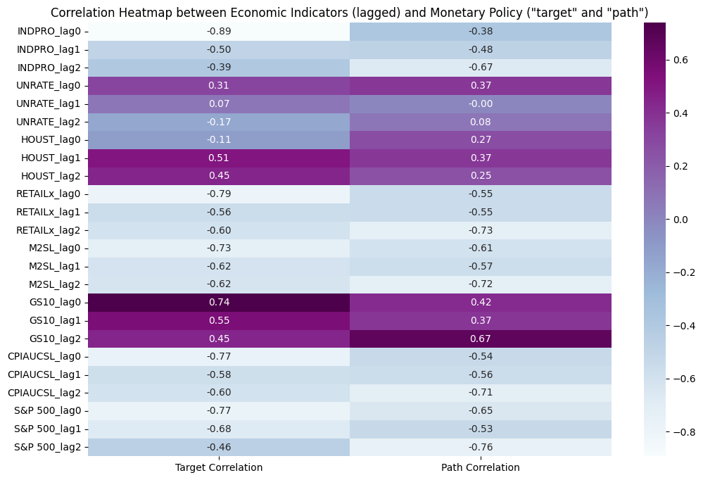

```python
def merge_data(monetary_df, data_tables):
    merged_data = []
    for data_table in data_tables:
        # Convert 'sasdate' to datetime format
        data_table['sasdate'] = pd.to_datetime(data_table['sasdate'])
        # Merge with monetary policy data
        merged_df = pd.merge(monetary_df, data_table, left_on='fomc', right_on='sasdate', how='inner')
        merged_data.append(merged_df)
    return merged_data

# Assume monetary_df is your monetary policy DataFrame
# Assume g1_data_table, g2_data_table, ..., g8_data_table are your economic indicator DataFrames
data_tables = [g1_data_table, g2_data_table, g3_data_table, g4_data_table, g5_data_table, g6_data_table, g7_data_table, g8_data_table]
merged_data_groups = merge_data(monetary_df, data_tables)

# Now merged_data_groups is a list of merged DataFrames for each group
merged_df_group1, merged_df_group2, merged_df_group3, merged_df_group4, merged_df_group5, merged_df_group6, merged_df_group7, merged_df_group8 = merged_data_groups

# Define a list of selected economic indicators for each group
selected_indicators_group1 = ['INDPRO']  # Example for Group 1, replace with your indicators
selected_indicators_group2 = ['UNRATE']
selected_indicators_group3 = ['HOUST']
selected_indicators_group4 = ['RETAILx']
selected_indicators_group5 = ['M2SL']
selected_indicators_group6 = ['GS10']
selected_indicators_group7 = ['CPIAUCSL']
selected_indicators_group8 = ['S&P 500']

# Define lag periods (𝑡, 𝑡 + 1, and 𝑡 + 2) for months
lag_periods = [0, 1, 2]

# Create a new DataFrame for correlations
correlation_df = pd.DataFrame()

# Loop through each group and selected economic indicators
for group_df, selected_indicators in zip([merged_df_group1, merged_df_group2, merged_df_group3, merged_df_group4, merged_df_group5, merged_df_group6, merged_df_group7, merged_df_group8],
                                         [selected_indicators_group1, selected_indicators_group2,selected_indicators_group3,selected_indicators_group4,selected_indicators_group5,selected_indicators_group6,selected_indicators_group7,selected_indicators_group8]):
    for indicator in selected_indicators:
        for lag in lag_periods:
            lagged_column = f'{indicator}_lag{lag}'
            group_df[lagged_column] = group_df[indicator].shift(lag)

            # Calculate the correlation between the lagged economic indicator and "target"
            correlation_target = group_df[['target', lagged_column]].corr().iloc[0, 1]

            # Calculate the correlation between the lagged economic indicator and "path"
            correlation_path = group_df[['path', lagged_column]].corr().iloc[0, 1]

            # Store the correlations in the correlation_df
            correlation_df.loc[f'{indicator}_lag{lag}', 'Target Correlation'] = correlation_target
            correlation_df.loc[f'{indicator}_lag{lag}', 'Path Correlation'] = correlation_path

# Create a correlation heatmap
plt.figure(figsize=(12, 8))
sns.heatmap(correlation_df, cmap='BuPu', annot=True, fmt='.2f')
plt.title('Correlation Heatmap between Economic Indicators (lagged) and Monetary Policy ("target" and "path")')
plt.show()
```

Industrial Production (INDPRO):

- Exhibits a pronounced negative relationship with the "target" factor when assessed concurrently (lag 0), highlighting a trend where an augmentation in the "target" factor correlates with a reduction in industrial production within the same month.
- The association with the "path" factor progressively becomes more negative as the months advance.